# SURF Akzeptanzbefragung

# 1 Die SURF Akzeptanzbefragung

Die SURF Akzeptanzbefragung erfasst Einstellungen, Präferenzen und Zahlungsbereitschaften von Haushalten in Bezug auf eine digitale Plattform zur netzdienlichen Steuerung steuerbarer Haushaltsgeräte. Der Fragebogen kombiniert allgemeine Einstellungsabfragen mit einem szenariobasierten Experimentalteil und deckt sowohl Haushalte mit als auch ohne derzeit verfügbare steuerbare Geräte ab.

## 1.1 Aufbau und Inhalte der Umfrage

**Die zentralen Inhaltsbereiche der Umfrage sind dabei, in Reihenfolge ihrer Erhebung:**

- **Primer: Erklärvideo zur SURF (erstellt in Kooperation mit dem AWSi)**
  - ca. 3-minütiges Erklärvideo über die wesentlichen Aspekte der SURF-Plattform, ihrer Funktionsweise und ihres Nutzens für Stromnetz und Teilnehmende.
- **Haushaltsausstattung mit SVE**
  - Besitz und geplante Anschaffung von Wallbox, Wärmepumpe, Batteriespeicher, Photovoltaikanlage und Energiemanagementsystem.
- **Allgemeine Einstellung zur SURF-Plattform**
  - Grundsätzliche Bewertung der Plattform.
  - Teilnahmebereitschaft, differenziert nach Haushalten mit und ohne vorhandene steuerbare Geräte.
- **Szenariobasierter Experimentalteil**
  - Einführung eines hypothetischen Nutzungsszenarios mit aktiver Teilnahme an der SURF-Plattform.
  - Annahme einer automatischen, zeitlich begrenzten Gerätesteuerung zur Behebung von Netzengpässen.
  - Zufällige Variation der jährlichen Häufigkeit von Steuerungseingriffen.
- **Eingriffspräferenzen für automatische Steuerung**
  - Entscheidung, welche Geräte grundsätzlich gesteuert werden dürfen.
  - Angabe der maximal akzeptierten Einschränkungen je Gerät (z. B. Ladeverzögerung, Temperaturabweichung, Einspeisereduktion, Restladung).
- **Finanzielle Präferenzen und Zahlungsbereitschaft**
  - Bevorzugte Form der Vergütung.
  - Präferierte Vergütungslogik (pauschal vs. leistungsabhängig).
  - Angabe eines jährlichen Mindestbetrags für die akzeptierten Einschränkungen.
  - Einschätzung der Sicherheit dieser Zahlungsbereitschaft.
- **Steuerungspräferenzen und Vertrauen**
  - Bedeutung individueller Kontroll- und Eingriffsmöglichkeiten.
- **Informationsbedarfe und App-Funktionen**
  - Bedarf an zusätzlichen Informationen.
  - Relevanz verschiedener Informationsinhalte (Netzzustand, Komfort-, Finanz- und Netzeffekte).
  - Bevorzugte Darstellungsformen und gewünschte Informationstiefe.
- **Teilnahmemotive**
  - Zentrales Motiv für eine potenzielle Teilnahme an der Plattform.
- **Soziodemografische Merkmale**
  - Alter, Haushaltsgröße, Einkommen, Stromkosten und Stromkostenanteil an Einkommen, Bildung, Geschlecht, Wohnform und Wohnort.

# 2 Erste Ergebnisse

## 2.1 Szenario

Um eine realistische Bewertung der Steuerungsmaßnahmen und Entschädigungen zu ermöglichen, wurden alle Teilnehmenden gebeten, sich in eine spezifische Nutzungssituation hineinzuversetzen. Durch die zufällige Variation der Steuerungshäufigkeit ({RandFreq}) wurde untersucht, wie die Akzeptanz mit der Belastung korreliert.

**Item: Einführung des Nutzungsszenarios**

*“Bitte stellen Sie sich für die nächsten Fragen folgendes Szenario vor:”*

- Sie nehmen bereits aktiv an der SURF-Plattform teil.
- Sie besitzen alle genannten Geräte (auch falls dem nicht so ist).
- Die SURF-Plattform steuert angeschlossene Geräte im Durchschnitt **{RandFreq}-mal im Jahr** automatisch (jeweils für 1-2 Stunden).
- Ihre Geräte werden für kurze Zeit automatisch gesteuert, Sie erhalten dafür aber eine finanzielle Vergütung und stabilisieren das Netz.

## 2.2 SVE

**Item: Haushaltsausstattung mit steuerbaren Geräten**

*“Wie im Video gezeigt, bezieht sich die SURF-Plattform auf steuerbare Geräte im Haushalt. Welche der steuerbaren Geräte besitzen Sie oder planen Sie anzuschaffen?”*

**Abgefragte Geräte:**

- Wallbox für Elektroauto
- Wärmepumpe
- Batteriespeicher (für Solaranlage oder Pufferspeicher)
- Photovoltaik-Anlage (Solaranlage)
- Energiemanagementsystem (Steuerungszentrale für Ihre Geräte)

**Antwortoptionen (je Gerät):**

- Besitze ich
- Plane ich in den nächsten 12 Monaten
- Plane ich langfristig
- Besitze ich nicht und plane keine Anschaffung

Der erste Analyseblock dient der Beschreibung der Stichprobe anhand der Ausstattung der Haushalte mit steuerbaren Geräten. Die Geräteausstattung ist sowohl ein zentrales inhaltliches Merkmal der Befragung als auch eine wichtige Grundlage für die Interpretation nachfolgender Ergebnisse, da sie maßgeblich die potenziellen Nutzungsmöglichkeiten der SURF-Plattform bestimmt.

[figure not shown]

### 2.2.1 SVE Gruppen

Auf Basis der Geräteausstattung und der angegebenen Anschaffungsabsichten lassen sich vier Haushaltsgruppen unterscheiden. Ein Teil der Stichprobe verfügt bereits über mindestens ein steuerbares Gerät und wird als aktive Flexibilitätsnutzer eingeordnet. Weitere Haushalte planen die Anschaffung entsprechender Geräte kurzfristig oder langfristig, während ein verbleibender Anteil weder Geräte besitzt noch Anschaffungsabsichten angibt. Diese Gruppierung bildet eine zentrale Grundlage für die Interpretation der nachfolgenden Analysen.

[figure not shown]

## 2.3 Partizipationsintention (PI)

Nachdem die Befragten über die Funktionsweise der Plattform informiert wurden, wurde die Bereitschaft zur Teilnahme erhoben. Dabei wurde methodisch zwischen Haushalten unterschieden, die bereits steuerbare Geräte besitzen, und solchen, bei denen dies (noch) nicht der Fall ist.

**Item: Partizipationsintention (Teilnahmebereitschaft)**

*Abhängig vom Besitzstatus wurde eine der folgenden zwei Varianten abgefragt:*

**Variante A: Reale Intention (für Besitzer von SVE)**

- “Ich möchte an der SURF-Plattform teilnehmen.”
- *(Filter: Mindestens ein Gerät vorhanden)*

**Variante B: Hypothetische Intention (für Nicht-Besitzer)**

- “Falls in meinem Haushalt zukünftig steuerbare Geräte (z. B. Wallbox, Wärmepumpe) verfügbar sind, möchte ich an der SURF-Plattform teilnehmen.”
- *(Filter: Kein Gerät vorhanden)*

**Antwortoptionen (5-stufige Likert-Skala):**

- 1 - Stimme überhaupt nicht zu
- 2 - Stimme eher nicht zu
- 3 - Teils, teils
- 4 - Stimme eher zu
- 5 - Stimme vollständig zu
- Weiß ich nicht

Während die Akzeptanz die grundsätzliche Einstellung der Befragten zur SURF-Plattform widerspiegelt, misst die Partizipationsintention (PI) die konkrete Bereitschaft, das eigene Haushaltssystem tatsächlich für eine netzdienliche Steuerung zur Verfügung zu stellen. Die Intention gilt in der psychologischen Forschung als der stärkste Prädiktor für tatsächliches zukünftiges Verhalten.

Methodisch wird in dieser Untersuchung zwischen zwei Ausgangslagen unterschieden:

- Reale Partizipationsintention: Befragte, die bereits steuerbare Geräte besitzen, bewerten ihre Bereitschaft zur unmittelbaren Teilnahme.
- Hypothetische Partizipationsintention: Befragte ohne entsprechende Hardware bewerten ihre Bereitschaft für den Fall einer zukünftigen Anschaffung.

### 2.3.1 PI zu Beginn

[figure not shown]

### 2.3.2 PI am Ende

#### 2.3.2.1 Nach Adoptionsstatus

[figure not shown]

### 2.3.3 PI Differenz Beginn-Ende

#### 2.3.3.1 Nach Adoptionsstatus

[figure not shown]

## 2.4 Steuerungsbereitschaft nach Gerät

Nach der Einführung in das Szenario wurden die Teilnehmenden gebeten, eine konkrete Auswahl zu treffen, welche ihrer (potenziellen) Geräte sie für die automatische Steuerung durch die SURF-Plattform freigeben würden.

**Item: Auswahl der Geräte**

*“Bitte geben Sie nun zunächst an, welche der folgenden Geräte in Ihrem Haushalt Sie von der SURF-Plattform **{RandFreq}-mal im Jahr** (jeweils für 1-2 Stunden) automatisch steuern lassen würden, um Netzengpässe zu beheben.”*

*“Wir bitten Sie, diese Entscheidungen so ernsthaft zu treffen, als würden Sie sie vertraglich festlegen.”*

**Abgefragte Geräte:**

- Wallbox
- Wärmepumpe
- Batteriespeicher
- Photovoltaik-Anlage

**Antwortoptionen (je Gerät):**

- Ja (Steuerung erlaubt)
- Nein (Keine Steuerung erlaubt)

[figure not shown]

## 2.5 Flexibilitätsbereitschaft

In diesem Abschnitt wurden die Teilnehmenden gebeten, für jedes zur Steuerung freigegebene Gerät das maximal akzeptable Maß an Einschränkung zu definieren. Diese Angaben bilden die Grundlage für die spätere Berechnung der notwendigen Entschädigung.

**Item: Maximale Einschränkung je Gerät**

*“Geben Sie pro Gerät in Ihrem Haushalt an, welche maximale Einschränkung Sie akzeptieren, wenn die SURF-Plattform dieses **{RandFreq}-mal im Jahr** (jeweils für 1-2 Stunden) automatisch zur Behebung eines Netzengpasses steuert.”*

*“Wir bitten Sie, diese Entscheidungen so ernsthaft zu treffen, als würden Sie sie vertraglich festlegen.”*

*(Hinweis: Im nächsten Schritt fragen wir Sie, welche finanzielle Vergütung Sie für die akzeptierten Einschränkungen verlangen.)*

**Abgefragte Dimensionen (je Gerät):**

- **Wallbox:** Zeitliche Verzögerung des Ladevorgangs
- **Wärmepumpe:** Kurzzeitige Abweichung von der Raumtemperatur
- **Batteriespeicher:** Mindest-Ladestand, der für den Eigenverbrauch verbleiben muss
- **Photovoltaik:** Grad der Einspeisereduktion bei Netzüberlastung

**Antwortformat:**

- 6-stufige Skala (von Stufe 0 “Geringe Flexibilität” bis Stufe 5 “Hohe Flexibilität”)

### 2.5.1 Generell

| Stufe | Wallbox | Wärmepumpe | Batteriespeicher | Photovoltaik |
| --- | --- | --- | --- | --- |
| 0 | 0,5 Std. | 0,0 °C | 90 % | 10 % |
| 1 | 1,0 Std. | 0,5 °C | 70 % | 30 % |
| 2 | 2,0 Std. | 1,0 °C | 50 % | 50 % |
| 3 | 3,0 Std. | 1,5 °C | 30 % | 70 % |
| 4 | 4,0 Std. | 2,0 °C | 10 % | 90 % |
| 5 | 5,0 Std. | 2,5 °C | 0-5 % | 100 % |

[figure not shown]

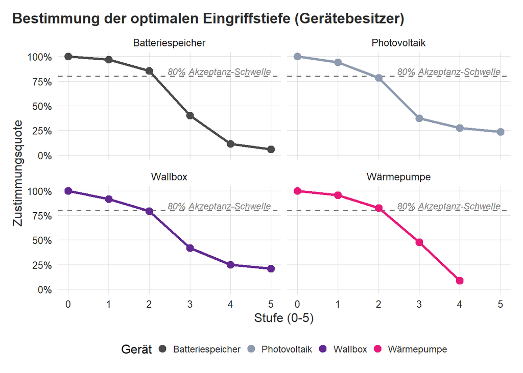

## 2.6 Erwartet Vergütung

In diesem zentralen Abschnitt des Experiments wurde der jährliche Mindestbetrag (Willingness-to-Accept) ermittelt. Um realistische Werte zu erhalten, wurde ein „Cheap Talk Script“ eingesetzt und den Befragten ihre individuellen Komfort-Einschränkungen noch einmal unmittelbar vor der Preisabfrage vor Augen geführt.

**Item: Erwarteter jährlicher Mindestbetrag**

*“Als nächstes möchten wir wissen, welche Vergütung Sie für Ihre Teilnahme an der SURF-Plattform verlangen.”*

**Wichtiger Hinweis – Bitte realistisch einschätzen (Cheap Talk):**

- In ähnlichen Studien nennen Teilnehmer oft Beträge, die höher sind, als sie real akzeptieren würden.
- Bedenken Sie: Hohe Vergütungen müssten über die Netzentgelte von allen Haushalten finanziert werden.
- Bitte nennen Sie den Betrag, den Sie tatsächlich als fairen Ausgleich akzeptieren würden.

**Zusammenfassung Ihrer gewählten Einschränkungen:**

- *(Hier wurden dem Teilnehmer seine zuvor gewählten maximalen Einschränkungen für Wallbox, Wärmepumpe, Batteriespeicher und PV-Anlage individuell zusammengefasst eingeblendet.)*

**Die Preisschätzungsfrage:**

*“Wie hoch ist Ihr jährlicher Mindestbetrag, damit Sie **{RandFreq}-mal im Jahr** für jeweils 1–2 Stunden die automatische Steuerung Ihrer Geräte mit den genannten Einschränkungen akzeptieren?”*

**Antwortoptionen (Auswahl):**

- 0 € / 15 € / 30 € / 50 € / 75 € / 100 € / 125 € / 150 € / 175 € / 200 € / 250 €
- Mehr als 250 € (Betrag bitte angeben)
- Ich möchte nicht teilnehmen, egal wie hoch die Bezahlung ist.
- Weiß ich nicht / Sonstiges

[figure not shown]

### 2.6.1 Nach Gerätetyp

[figure not shown]

### 2.6.2 Nach Szenario

[figure not shown]

## 2.7 Form und Struktur der Vergütung

Dieser Block wird in der Umfrage, welche diesen Daten zugrunde liegt, vor der erwarteten Vergütung abgefragt. Aus diesem Grund kann das Ausmaß der erwarteten Vergütung nach der präferierten Vergütungsform und -struktur analysiert werden.

### 2.7.1 Form der Vergütung

**Item: Bevorzugte Form der Vergütung**

*“Wie möchten Sie für Ihre Teilnahme von der SURF-Plattform vergütet werden?”*

**Optionen:**

- Verringerung Ihrer jährlichen Stromrechnung
- Direkte Gutschrift auf Ihr Konto
- Bonuspunkte oder Gutscheine für Prämien
- Ich habe keine Präferenz

[figure not shown]

### 2.7.2 Struktur der Vergütung

Ergänzend zur Auszahlungsform wurde die präferierte Vergütungslogik abgefragt. Hierbei standen verschiedene Modelle zur Auswahl, die sich im Grad der Leistungsorientierung (pauschal vs. nutzungsabhängig) unterscheiden.

**Item: Gewünschte Struktur der Vergütung**

*“Wofür möchten Sie im Rahmen der SURF-Plattform finanziell vergütet werden?”*

**Optionen:**

- Nur für die Teilnahme (alle erhalten denselben Betrag, unabhängig davon, wie viel Flexibilität sie beigetragen haben)
- Nur für die tatsächliche Menge bereitgestellter Flexibilität (nur wer mehr beiträgt, erhält auch mehr Geld)
- Für die Teilnahme und die Menge der bereitgestellten Flexibilität (alle erhalten einen Grundbetrag, wer mehr beiträgt, erhält jedoch auch mehr zusätzliches Geld)
- Ich habe keine Präferenz

[figure not shown]

### 2.7.3 Form und Struktur der Vergütung: Typologisierungsansätze und Vergütungserwartungen

Die Kombination aus der Vergütungsform (dem Auszahlungsweg, z. B. Stromrechnung vs. Bankkonto) und der Vergütungsstruktur (der Berechnungslogik, z. B. Fixum vs. variable Zahlung) erlaubt es, spezifische Nutzer-Typologien zu identifizieren. Diese Matrix-Analyse gibt Aufschluss darüber, welche „Anreiz-Pakete“ in der Stichprobe dominieren und wie die gewählte Kombination mit der monetären Erwartungshaltung korreliert.

[figure not shown]

## 2.8 Kontrolloptionen

**Item: Bedeutung von Kontroll- und Eingriffsmöglichkeiten**

*“Wie wichtig sind Ihnen die folgenden Möglichkeiten im Rahmen der automatischen Steuerung durch die SURF-Plattform?”*

**Abgefragte Aspekte:**

- Zeitliche Flexibilität (config_depth): Selbst festlegen zu können, zu welchen Tageszeiten Geräte in meinem Haushalt durch die SURF-Plattform gesteuert werden können.
- Override-Option (config_override): Die Möglichkeit, die automatische Steuerung jederzeit und sofort zu beenden.
- Geräteauswahl (config_device): Selbst festlegen zu können, welche meiner Geräte durch die SURF-Plattform gesteuert werden können, und welche nicht.

**Antwortoptionen (Skala 0 bis 4):**

- 0 - Überhaupt nicht wichtig
- 1 - Eher unwichtig
- 2 - Teils, teils
- 3 - Eher wichtig
- 4 - Sehr wichtig

[figure not shown]

[figure not shown]

## 2.9 Informations und Entscheidungstransparenz

Transparenz gilt als Schlüssel für die Akzeptanz automatisierter Systeme. Hier wurde abgefragt, welche Informationstiefe die Befragten benötigen, um den Entscheidungen der SURF-Plattform vertrauen zu können.

Item: Mindest-Informationsbedarf für Systemvertrauen

“Wie viel Informationen über die automatischen Entscheidungen der SURF-Plattform benötigen Sie mindestens, um diesen vertrauen zu können?”

Antwortoptionen:

- Basisinformationen: Nur wesentliche Fakten (Mein Flexibilitätsbeitrag, Auswirkungen auf den Haushalt, finanzielle Gewinne).
- KI-Inputdaten: Zusätzlich die zugrunde liegenden Daten (Netzsituation, Auslastungsvorhersagen, Wetter).
- Interaktive Erklärung: Die KI soll auf Nachfrage Details zu konkreten Entscheidungen erklären können (Explainable AI).

[figure not shown]

[figure not shown]

## 2.10 Teilahmemotive

Zum Abschluss der inhaltlichen Analyse betrachten wir die Teilnahmemotive. Hierbei wurde erhoben, welcher Aspekt für die Befragten den ausschlaggebenden Impuls für eine Teilnahme an der SURF-Plattform darstellt. Dies ist für das Marketing und die Zielgruppenansprache der Plattform von zentraler Bedeutung.

Item: Zentrales Teilnahmemotiv

“Was motiviert Sie am meisten zur Teilnahme an der SURF-Plattform?”

Optionen:

- Finanzielle Vergütung
- Technologisches Interesse
- Umweltschutz
- Netzstabilität
- Sonstiges
- Weiß ich nicht

[figure not shown]